# Part II - Communicate Data Insights - Ford GoBike System

## by Funto Adedeji

## Investigation Overview

In the part 1 of this project, I carried out data wrangling and used Python visualization libraries to explore the dataset, starting from univariate exploration to Bivariate and Multivariate Exploration.

In this part 2 of the project, I will show the interesting relationships, trends and insights discovered in the exploratory analysis.

## Dataset Overview

The raw dataset contains 183,412 records with 16 features for Ford GoBike System in a bike-sharing system covering the greater San Francisco Bay area. The 16 features include; duration_sec, start_time, end_time, start_station_id, start_station_name, start_station_latitude, start_station_longitude, end_station_id, end_station_name, end_station_latitude, end_station_longitude, bike_id, user_type, member_birth_year, member_gender and bike_share_for_all_trip.

## Visualization 1

### 1. Distribution of Riders by User_type

- most of the riders are suscribers

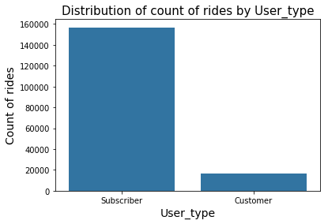

## Visualization 2

### 2. Age Distribution of Riders

- We have more riders within the age of 30 and 40 years

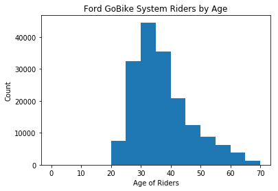

## Visualization 3

### 3. Relationship between rider's age of both customer & suscribers and trip duration(min) showing by gender

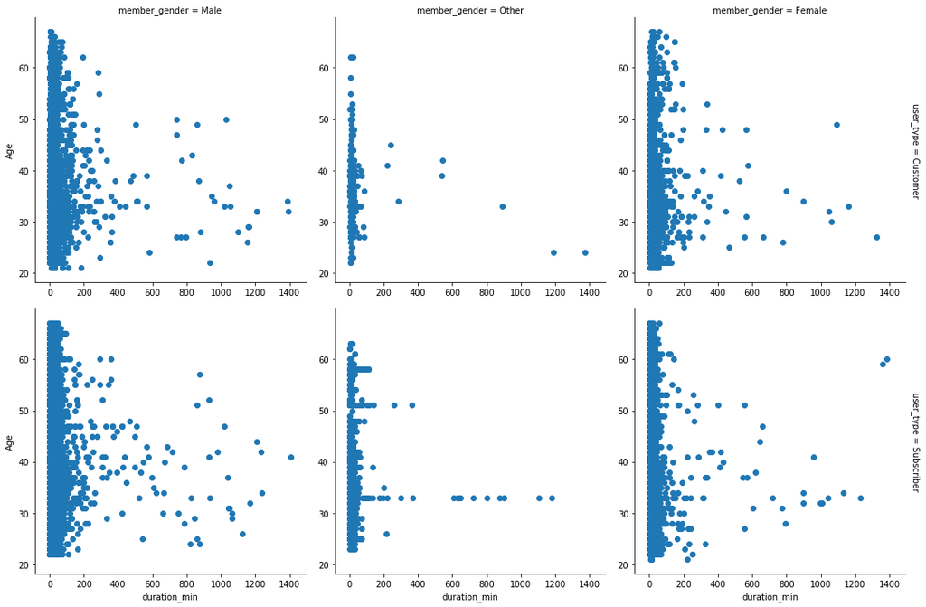

## Visualisation 4

### Relationship between Riders' Trip duration and days of the week

- Suscribers makes shorter trips both on week days and weekends compared to Customers who makes longer trip with the longest on weekends.

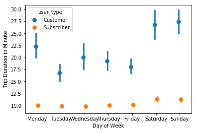

## Visualisation 5

### Relationship between riders' usage hours and the weekdays

- This further emphasize a high record of usage in the morning and evening for Riders (Customers & Suscribers) on weekdays (Mondays to Friday).
- Customers make trips on weekends.

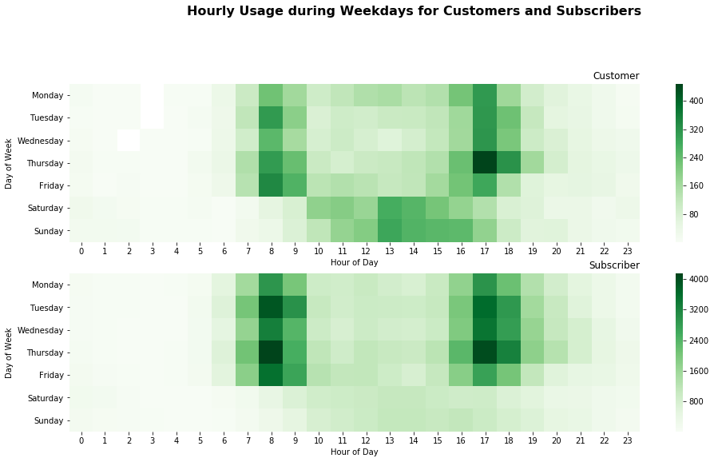

### Submission

If you are using classroom workspace, you can choose from the following two ways of submission:

1. **Submit from the workspace**. Make sure you have removed the example project from the /home/workspace directory. You must submit the following files:
   - Part_I_notebook.ipynb
   - Part_I_notebook.html or pdf
   - Part_II_notebook.ipynb
   - Part_I_slides.html
   - README.md
   - dataset (optional)
1. **Submit a zip file on the last page of this project lesson**. In this case, open the Jupyter terminal and run the command below to generate a ZIP file.

   ```
   zip -r my_project.zip .
   ```

   The command abobve will ZIP every file present in your /home/workspace directory. Next, you can download the zip to your local, and follow the instructions on the last page of this project lesson.